# Tableau Dashboards

#### Vaishnavi Shankar Devadig, 2024

### Introduction

Leaving out the hundred other tableau Dashboards I have been creating, deleting, tweaking, hiding, at the moment, I want to show my dashboards on two things I love the most! - **Indian Food** and the legend himself, **Shahrukh Khan!**

** cries of joy **

Here are the two dashboards I would like to display for now. I will keep updating as and when my brain strikes a new idea and I decide to experiment with some new type of chart :)

### Flavors of India

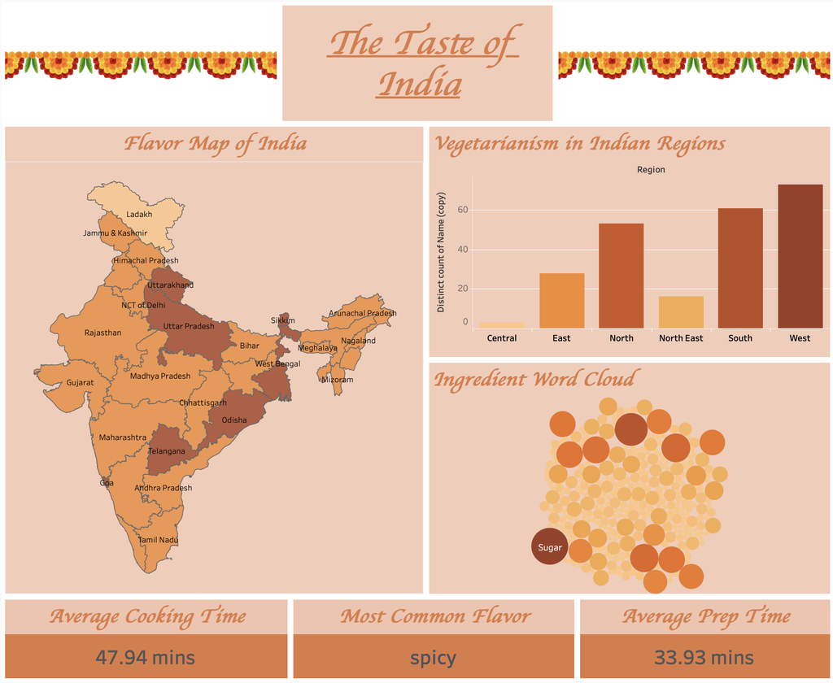

Tableau Link: https://public.tableau.com/app/profile/vaishnavi.devadig/viz/TheTasteofIndia/Dashboard1

- The dashboard shows flavor profile of each state on hovering over the India Map.
- It displays the relevance of vegetarianism in different regions.
- The most used ingredients in Indian cooking.
- The average prepping and cooking time.
- The most prominent flavor in Indian cooking.

### Shahrukh Khan Filmography

[figure not shown]

Tableau Link: https://public.tableau.com/app/profile/vaishnavi.devadig/viz/ShahrukhKhan_17077719601070/Dashboard1

- The dashboard displays all the Shahrukh Khan-led movies by genre.
- The first layer of the donut chart has genres.
- The second layer has the movies under the selected genre.
- The third has the total movie length for each genre.
- The final layer extends for all those movies for which he has won a FilmFare India Award.
- The line chart below shows the number of box office successes he has had in a year.